# Radar Chart

올림푸스

2020-04-27

- 목적: 레이더 차트를 통해 고객 집단별 구매 행태를 비교하고, 선호 상품군을 파악한다.

```r
# 패키지 로드
library(dplyr)
library(fmsb)

# 데이터 로드
load("~/Documents/R/R_workspace/easy_r/LD/normal_client0.rda")
load("~/Documents/R/R_workspace/easy_r/LD/vip_client0.rda")
```

# 1. Vip - Normal Client 레이더 차트

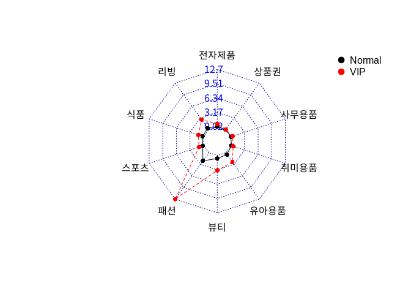

```r
all <- rbind(normal_client, vip_client)

all$class2 <- 0 #Normal
all[all$CLNT_CL == 10, 'class2'] <- 1 #VIP

t_radar <- all %>%
  group_by(class2) %>%
  summarise(
    전자제품 = mean(C1_CT),
    리빙 = mean(C2_CT),
    식품 = mean(C3_CT),
    스포츠 = mean(C4_CT),
    패션 = mean(C5_CT),
    뷰티 = mean(C6_CT),
    유아용품 = mean(C7_CT),
    취미용품 = mean(C8_CT),
    사무용품 = mean(C9_CT),
    상품권 = mean(C10_CT)
  )

t_radar <- as.data.frame(t_radar)
t_radar <- t_radar[-1] # CLNT_CL 지워줌

a <- range(t_radar)

t_radar <- rbind(rep(a[2], 10), rep(a[1], 10), t_radar)

rownames(t_radar) <- c('Max', 'Min', 'Normal', 'VIP')

radarchart(t_radar,
           axistype = 1,
           caxislabels = c( round(a[1], 2),  # 최소값
                            round((a[2]-a[1])*0.25, 2), # 25%
                            round((a[2]-a[1])*0.50, 2), # 50%
                            round((a[2]-a[1])*0.75, 2), # 75%
                            round(a[2], 2) ) # 100%
)

colors_in = c('black', 'red')

a <- paste(rownames(t_radar)[3])
b <- paste(rownames(t_radar)[4])

legend(x='topright', y=1,
       legend=c(a, b),
       bty='n',pch=20, col=colors_in, text.col='black', cex=1, pt.cex=2)
```

### 인사이트

- Vip 고객이 Normal 고객보다 구매금액이 현저하게 높은 것을 알 수 있으며, 특히 패션 매출이 가장 높다.

# 2. Normal Client 고객 분류별 레이더 차트

```r
## Normal Client의 고객분류간 상품 구매를 알 수 있는 레이더 차트 함수 생성
radar <- function(table, type1 = c(1:9), type2 = c(1:9) ) {
  t_radar <- table %>%
    filter(CLNT_CL == type1 | CLNT_CL == type2) %>%
    group_by(CLNT_CL) %>%
    summarise(
      전자제품 = mean(C1_CT),
      리빙 = mean(C2_CT),
      식품 = mean(C3_CT),
      스포츠 = mean(C4_CT),
      패션 = mean(C5_CT),
      뷰티 = mean(C6_CT),
      유아용품 = mean(C7_CT),
      취미용품 = mean(C8_CT),
      사무용품 = mean(C9_CT),
      상품권 = mean(C10_CT)
  )

  t_radar <- as.data.frame(t_radar)
  t_radar <- t_radar[-1] # CLNT_CL 지워줌

  a <- range(t_radar)

  t_radar <- rbind(rep(a[2], 10), rep(a[1], 10), t_radar)

  rownames(t_radar) <- c('Max', 'Min', type1, type2)

  radarchart(t_radar,
             axistype = 1,
             caxislabels = c( round(a[1], 2),  # 최소값
                              round((a[2]-a[1])*0.25, 2), # 25%
                              round((a[2]-a[1])*0.50, 2), # 50%
                              round((a[2]-a[1])*0.75, 2), # 75%
                              round(a[2], 2) ) # 100%
  )

  colors_in = c('black', 'red')

  # c <- ifelse(rownames(t_radar)[3] == '1', '10~20대 남성', '나머지')
  # print(c)

    a <- paste(ifelse(type1 == 1, '10~20대 남성',
                      ifelse(type1 == 2, '10대 여성',
                             ifelse(type1 == 3, '20대 여성',
                                    ifelse(type1 == 4, '30대 남성',
                                           ifelse(type1 == 5, '30대 여성',
                                                  ifelse(type1 == 6, '40~50대 남성',
                                                         ifelse(type1 == 7, '40~50대 여성',
                                                                ifelse(type1 == 8, '60~80대 남성', '60~80대 여성')))))))), '고객')

    b <- paste(ifelse(type2 == 1, '10~20대 남성',
                      ifelse(type2 == 2, '10대 여성',
                             ifelse(type2 == 3, '20대 여성',
                                    ifelse(type2 == 4, '30대 남성',
                                           ifelse(type2 == 5, '30대 여성',
                                                  ifelse(type2 == 6, '40~50대 남성',
                                                         ifelse(type2 == 7, '40~50대 여성',
                                                                ifelse(type2 == 8, '60~80대 남성', '60~80대 여성')))))))), '고객')


    legend(x='topright', y=1,
           legend=c(a, b),
           bty='n',pch=20, col=colors_in, text.col='black', cex=1,pt.cex=2 )



}
```

## (1) 10~20대 남성 vs 10대 여성

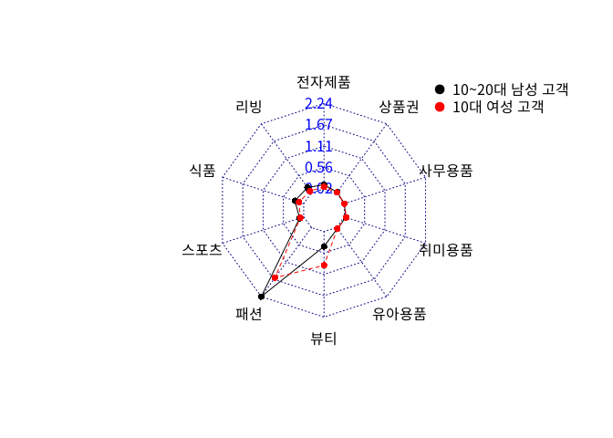

```r
# 10~20대 남/ 10대 여
radar(normal_client, 1, 2)
```

### 인사이트

10~20대 남성 고객과 10대 여성 고객 모두 패션의 매출이 가장 높았으며, 남성과 달리 여성의 경우 뷰티의 매출도 높은 것을 알 수 있다.

## (2) 10~20대 남성 vs 20대 여성

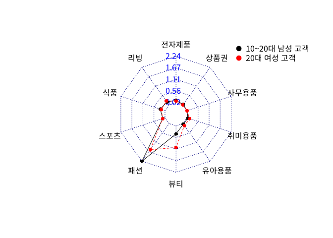

```r
# 10-20대 남 / 20대 여
radar(normal_client, 1, 3)
```

### 인사이트

10~20대 남성 고객과 20대 여성 고객 모두 패션의 매출이 가장 높았으며, 남성과 달리 여성의 경우 뷰티의 매출도 높은 것을 알 수 있다.

## (3) 30대 남성 vs 30대 여성

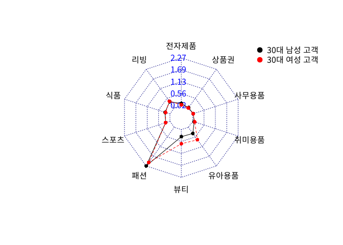

```r
# 30대 남 / 30대 여
radar(normal_client, 4, 5)
```

### 인사이트

- 30대 남성과 여성은 1~3 순위가 패션, 유아용품, 뷰티로 동일한 양상을 보였다.
- 남녀 패션 매출은 비슷했으나 유아용품과 뷰티에서는 차이를 볼 수 있었다.

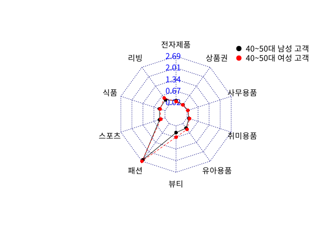

```r
# 40대 남 / 40대 여
radar(normal_client, 6, 7)
```

### 인사이트

40~50대 남녀 고객은 비슷한 구매 행태를 보였다.

## (5) 60~80대 남성 vs 60~80대 여성

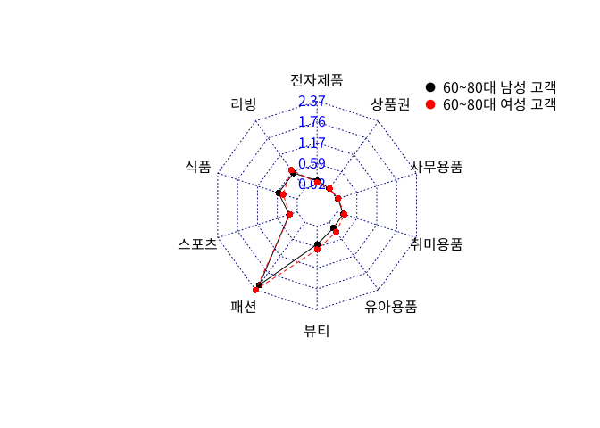

```r
# 60-80대 남 / 60-80대 여
radar(normal_client, 8, 9)
```

### 인사이트

역시 패션 매출이 가장 높았으며, 식품이 유독 다른 연령대에 비해 남성과 여성 둘다 구매수가 많았다. 나이가 증가함에 따라 영양제와 같은 건강기능식품에 관심이 증대하였을 것으로 추측된다.

# 3. 특정 집단과 개인 선호 상품군 레이더 차트

## 클러스터링 수행

```r
# 모든 고객을 담은 테이블 생성
all <- rbind(normal_client, vip_client)

# 상품 구매 비율 변수만으로 클러스터링 시행하기 위해 테이블 생성
df_cluster <- all[, c(9:18)]

# 샘플링
set.seed(1234)
n <- nrow(df_cluster)
sample <- sample(n, replace = F, .01*n)

# 클러스터 개수 구하기
df_cluster_test <- df_cluster[sample, ]
# nc <- NbClust(df_cluster_test, method = 'kmeans')
# NbClust 수행 결과 3이 나옴

# 클러스터링 수행
set.seed(1234)
kmc <-kmeans(df_cluster, centers = 3)

# 클러스터링 변수 추가
all$Cluster_CL <- kmc$cluster
```

## radar 차트를 그리기 위해 data frame 구성

```r
t_radar <- all %>%
  group_by(Cluster_CL) %>%
  summarise(
    전자제품 = mean(C1_CT),
      리빙 = mean(C2_CT),
      식품 = mean(C3_CT),
      스포츠 = mean(C4_CT),
      패션 = mean(C5_CT),
      뷰티 = mean(C6_CT),
      유아용품 = mean(C7_CT),
      취미용품 = mean(C8_CT),
      사무용품 = mean(C9_CT),
      상품권 = mean(C10_CT)
  )

  t_radar <- as.data.frame(t_radar)
  t_radar <- t_radar[-1] # CLNT_CL 지워줌

  a <- range(t_radar)

  t_radar <- rbind(rep(a[2], 10), rep(a[1], 10), t_radar)

  rownames(t_radar) <- c('Max', 'Min', 'Cluster1', 'Cluster2', 'Cluster3')

  t_radar
```

```
##             전자제품        리빙        식품      스포츠        패션
## Max      5.566137404 5.566137404 5.566137404 5.566137404 5.566137404
## Min      0.005147595 0.005147595 0.005147595 0.005147595 0.005147595
## Cluster1 0.079269899 0.183422906 0.137030205 0.224091970 5.566137404
## Cluster2 0.262759319 1.603786905 0.819179211 0.600932256 1.548022574
## Cluster3 0.072167326 0.132471880 0.141465039 0.072423541 0.722339417
##                 뷰티    유아용품    취미용품    사무용품      상품권
## Max      5.566137404 5.566137404 5.566137404 5.566137404 5.566137404
## Min      0.005147595 0.005147595 0.005147595 0.005147595 0.005147595
## Cluster1 0.359826085 0.254953028 0.035925924 0.038205573 0.005147595
## Cluster2 0.519708484 1.712943271 0.459756456 0.189823240 0.060877268
## Cluster3 3.541306186 0.095423140 0.037851549 0.023238733 0.007498569
```

## radar chart를 통한 cluster별 고객 특성 파악

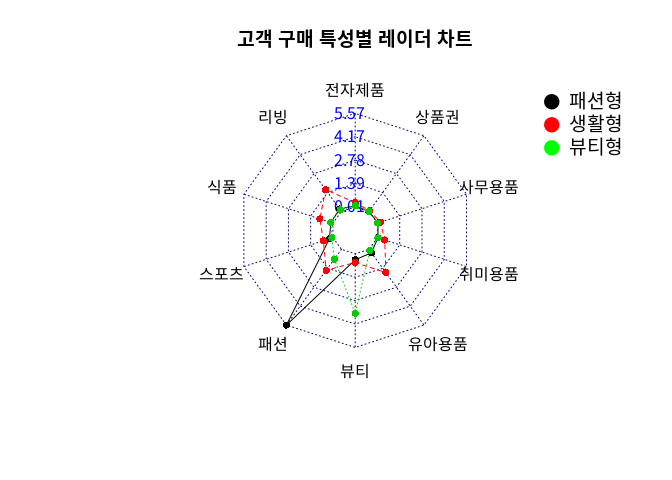

```r
radarchart(t_radar,
           axistype = 1,
           caxislabels = c( round(a[1], 2),  # 최소값
                            round((a[2]-a[1])*0.25, 2), # 25%
                            round((a[2]-a[1])*0.50, 2), # 50%
                            round((a[2]-a[1])*0.75, 2), # 75%
                            round(a[2], 2) ),# 100%
           title = '고객 구매 특성별 레이더 차트'
)

colors_in = c('black', 'red', 'green')

a <- '패션형'
b <- '생활형'
c <- '뷰티형'

legend(x='topright', y=1,
       legend=c(a, b, c),
       bty='n',pch=20, col=colors_in, text.col='black', cex=1.2,pt.cex=3 )
```

### 인사이트

3개의 집단으로 클러스터링한 결과 크게 패션형, 생활형, 뷰티형 집단으로 나눌 수 있었다.

## 집단과 개인 선호 상품군 비교

```r
# 자신의 클래스 번호, 클러스터링 번호, 고객 번호를 넣어서 고객 한 명의 성향을 확인해주는
# radar라는 함수를 생성
radar <- function(table, class = c(1:10), CL_num = c(1:3), CLNT_Number = numeric ) {
  t_radar <- table %>%
    filter(CLNT_CL == class & CL_num == Cluster_CL) %>%
    summarise(
      전자제품 = mean(C1_CT),
      리빙 = mean(C2_CT),
      식품 = mean(C3_CT),
      스포츠 = mean(C4_CT),
      패션 = mean(C5_CT),
      뷰티 = mean(C6_CT),
      유아용품 = mean(C7_CT),
      취미용품 = mean(C8_CT),
      사무용품 = mean(C9_CT),
      상품권 = mean(C10_CT)
    )

  person <- table %>%
    filter(CLNT_ID == CLNT_Number) %>%
    summarise(
      전자제품 = sum(C1_CT),
      리빙 = sum(C2_CT),
      식품 = sum(C3_CT),
      스포츠 = sum(C4_CT),
      패션 = sum(C5_CT),
      뷰티 = sum(C6_CT),
      유아용품 = sum(C7_CT),
      취미용품 = sum(C8_CT),
      사무용품 = sum(C9_CT),
      상품권 = sum(C10_CT)
    )

  t_radar <- rbind(t_radar, person)

  a <- range(t_radar)

  t_radar <- rbind(rep(a[2], 10), rep(a[1], 10), t_radar)

  rownames(t_radar) <- c('Max', 'Min', 'Class_Average', 'CLNT_ID')

  x <- paste(
    (ifelse(class == 1, '10~20대 남성',
            ifelse(class == 2, '10대 여성',
                   ifelse(class == 3, '20대 여성',
                          ifelse(class == 4, '30대 남성',
                                 ifelse(class == 5, '30대 여성',
                                        ifelse(class == 6, '40대 남성',
                                               ifelse(class == 7, '40대 여성',
                                                      ifelse(class == 8, '50~80대 남성', '50~80대 여성'))))))))
     ),
     '+',
    (ifelse(CL_num == 1, '패션형',
            ifelse(CL_num == 2, '생활형', '뷰티형') )



    )
  )


  y <- paste('고객 ID', CLNT_Number)

  radarchart(t_radar,
             axistype = 1,
             caxislabels = c( round(a[1], 2),  # 최소값
                              round((a[2]-a[1])*0.25, 2), # 25%
                              round((a[2]-a[1])*0.50, 2), # 50%
                              round((a[2]-a[1])*0.75, 2), # 75%
                              round(a[2], 2) ), # 100%
             title=paste(y,'와 ', x,'비교')
  )

  colors_in = c('black', 'red')

  legend(x='topright', y=1,
         legend=c(x, y),
         bty='n',pch=20, col=colors_in, text.col='black', cex=1, pt.cex=2 )

}
```

## Radar 함수 호출 예시로 결과 파악

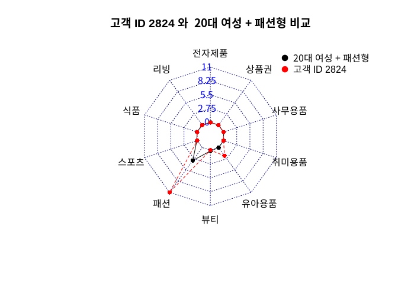

```r
radar(all, 3, 1, 2824)
```

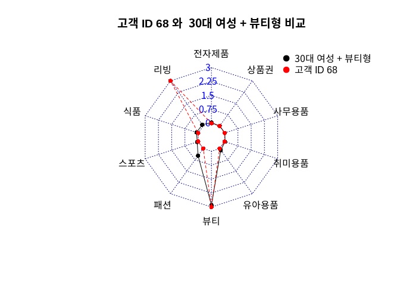

```r
radar(all, 5, 3, 68)
```

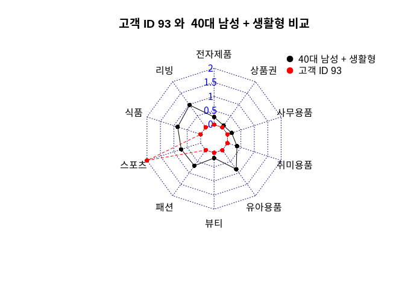

```r
radar(all, 6, 2, 93)
```